# Exercise_20170920

# 1 Introduction

You will work with “diamonds” dataset. First, **ggplot2** is loaded. This package also includes this dataset.

```r
suppressPackageStartupMessages(library(dplyr))
library(ggplot2)
```

Data is loaded with *data()*.

```r
data("diamonds")
diamonds
```

```
## # A tibble: 53,940 x 10
##    carat       cut color clarity depth table price     x     y     z
##    <dbl>     <ord> <ord>   <ord> <dbl> <dbl> <int> <dbl> <dbl> <dbl>
##  1  0.23     Ideal     E     SI2  61.5    55   326  3.95  3.98  2.43
##  2  0.21   Premium     E     SI1  59.8    61   326  3.89  3.84  2.31
##  3  0.23      Good     E     VS1  56.9    65   327  4.05  4.07  2.31
##  4  0.29   Premium     I     VS2  62.4    58   334  4.20  4.23  2.63
##  5  0.31      Good     J     SI2  63.3    58   335  4.34  4.35  2.75
##  6  0.24 Very Good     J    VVS2  62.8    57   336  3.94  3.96  2.48
##  7  0.24 Very Good     I    VVS1  62.3    57   336  3.95  3.98  2.47
##  8  0.26 Very Good     H     SI1  61.9    55   337  4.07  4.11  2.53
##  9  0.22      Fair     E     VS2  65.1    61   337  3.87  3.78  2.49
## 10  0.23 Very Good     H     VS1  59.4    61   338  4.00  4.05  2.39
## # ... with 53,930 more rows
```

# 2 Exercise 1

1. Calculate for each “clarity”-group of the diamonds the min, max, median and standard deviation of price. The column names are “price_median”, “price_min”, “price_max”, and “price_sd”.
2. Which clarity refers to the highest median price? (Use the result from a) and calculate this result with filtering. Hint: check out function **which.max()**. It might help)

```r
# a)
diamonds_clarity_price <- diamonds %>%
  group_by(clarity) %>%
  summarise(price_median = median(price),
            price_min = min(price),
            price_max = max(price),
            price_sd = sd(price))

# b)
diamonds_clarity_price$clarity[which.max(diamonds_clarity_price$price_median)]
```

```
## [1] SI2
## Levels: I1 < SI2 < SI1 < VS2 < VS1 < VVS2 < VVS1 < IF
```

# 3 Exercise 2

Calculate an additional variable in the dataframe *diamonds*, called “outer_volume”, which is the product of x, y, and z.

```r
diamonds <- diamonds %>%
  mutate (outer_volume = x * y * z)
```

# 4 Exercise 3

You will create a plot, that is modified and extended in each sub-task.

1. Create a scatter-plot with **ggplot2**, showing “price” vs. “outer_volume”.
2. Find out how you can show only a zoomed area and show only data in the range of “outer_volume” of 0 to 600 mm^3.
3. Find out how to modify x- and y-labels and rename x-label “Outer Volume [mm^3]” and y-label “Price [$]”
4. Find out how to define a plot-title and use the title “Diamonds: Price and Outer Volume”
5. Besides x and y-variable, also color can be used as additional dimension for plotting. Find out how to plot each points color with reference to its “clarity”.

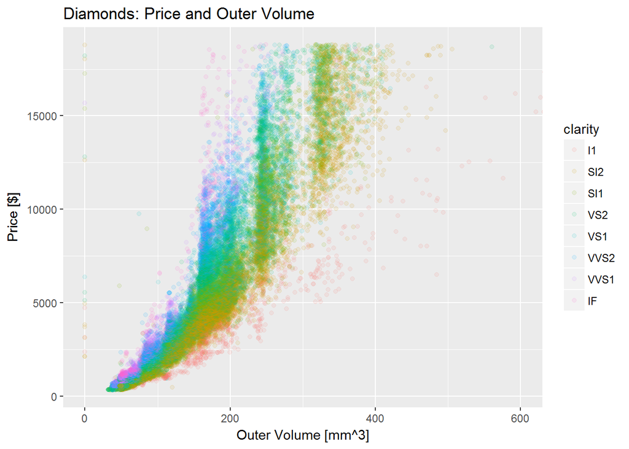

```r
g <- ggplot (diamonds, aes(x = outer_volume, y = price, col = clarity))
g <- g + geom_point(alpha = .1)
g <- g + coord_cartesian(xlim = c(0, 600))
g <- g + xlab ("Outer Volume [mm^3]")
g <- g + ylab ("Price [$]")
g <- g + ggtitle ("Diamonds: Price and Outer Volume")
g
```

# 5 Exercise 4

1. Create a filtered dataset, called **diamonds_filt**, which filters data for
- outer_volume > 0
- price between 500 and 15000 $.
2. Calculate the filter-ratio in percentage (nr. of kept observations in filtered vs. original (unfiltered) dataset)?

```r
diamonds_filt <- diamonds %>%
  filter (outer_volume > 0) %>%
  filter (price > 500 & price < 15000)

filter_ratio <- nrow(diamonds_filt) / nrow(diamonds) * 100
```

Good Luck!